# Finding a Place to Live

# Welcome to Dallas Guide for Incoming GLPers

Welcome to the PMG Graduate Leadership Program! We’re so excited to welcome you to the team! Below you’ll find helpful information on apartment hunting, transportation, local resources, and recommendations from fellow PMGers!

Office Address 2601 Olive St  
Floor 19  
Dallas, TX 75201

Proj. Start Date Monday, June 7th, 2027

Guide Topics Neighborhoods  
Apartments  
Transportation  
Weather  
Driver's License & Registration  
PMGer Recommendations  
Helpful Resources

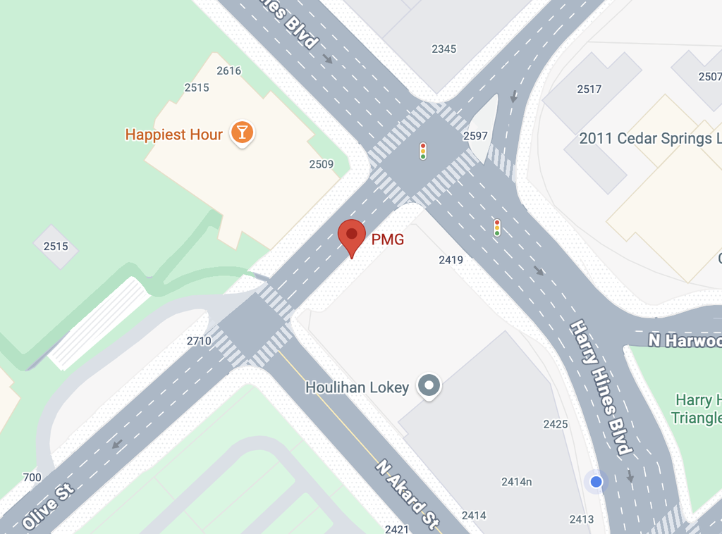

Finding an apartment in Dallas is fairly straightforward, but prices, incentives, and utility costs can vary significantly between neighborhoods and buildings. The information below covers where to search, common move-in specials, electricity, parking, and the fees you’ll likely encounter before signing a lease.

**Neighborhoods**

Choosing where to live can have a major impact on your commute, budget, and day-to-day experience in Dallas. The neighborhoods below are popular starting points for incoming GLPers.

### 📍 Uptown

🚶 Walk to PMG

Nightlife Katy Trail Walkable

Walkable to the office, McKinney Avenue trolley, Katy Trail, and nightlife. The most popular choice for new GLPers.

$2,400–$2,800+

[View on Google Maps →](https://www.google.com/search?q=uptown+dallas)

### 📍 Knox–Henderson

🚗 10 min

Restaurants Shopping Patios

Trendy shopping and dining near Highland Park and SMU. Great option for client dinners and weekends.

~$1,800

[View on Google Maps →](https://www.google.com/search?q=knox+henderson+dallas)

### 📍 Oak Lawn

🚗 8 min

Katy Trail Turtle Creek Residential

Quiet residential neighborhood with quick access to Uptown, Love Field and the Medical District.

$1,900–$2,200

[View on Google Maps →](https://www.google.com/search?q=oak+lawn+dallas)

### 📍 Deep Ellum

🚗 10 min

Live Music Nightlife Arts

Known for murals, live music, breweries and one of the best nightlife scenes in Dallas.

~$1,950

[View on Google Maps →](https://www.google.com/search?q=deep+ellum+dallas)

### 📍 Bishop Arts

🚗 15 min

Coffee Restaurants Local Shops

Historic Oak Cliff neighborhood with independent restaurants, boutiques and a relaxed atmosphere.

$1,300–$1,500

[View on Google Maps →](https://www.google.com/search?q=bishop+arts+dallas)

### 📍 Lower Greenville

🚗 12 min

Bars Restaurants Young Professionals

A favorite among young professionals with a lively restaurant and bar scene close to Uptown.

~$1,700

[View on Google Maps →](https://www.google.com/search?q=lower+greenville+dallas)

### Suburban Options

If you’re comfortable with a longer commute, the suburbs offer lower rent, larger apartments, and plenty of dining, shopping, and entertainment. Many PMGers choose these areas to maximize space and value while staying within a reasonable drive of the Uptown office.

### 📍 Richardson

🚗 25–30 min

Budget Friendly UT Dallas Quiet

A great value option with a quieter suburban feel. Close to UT Dallas and the Telecom Corridor, making it a popular choice for those wanting lower rent and more space.

$1,300–$1,400

[View on Google Maps →](https://www.google.com/search?q=richardson+tx)

### 📍 Addison

🚗 20–25 min

Restaurants Nightlife Central

Centrally located between Uptown, Plano, and Carrollton with one of the largest restaurant scenes in North Texas.

$1,450–$1,550

[View on Google Maps →](https://www.google.com/search?q=addison+tx)

### 📍 Plano

🚗 30–35 min

Corporate Legacy West Family Friendly

Home to Legacy West and several corporate headquarters. Offers newer apartments, excellent shopping, and a suburban lifestyle.

$1,350–$1,450

[View on Google Maps →](https://www.google.com/search?q=plano+tx)

### 📍 Frisco

🚗 35–45 min

New Apartments Sports Shopping

One of the fastest-growing cities in the country with modern apartment communities, retail, entertainment, and sports venues.

$1,300–$1,400

[View on Google Maps →](https://www.google.com/search?q=frisco+tx)

### 📍 Las Colinas

🚗 20–25 min

Airport Access Canals Corporate

Known for its canal walk, corporate campuses, and quick access to both DFW Airport and Uptown. A balanced option for work and travel.

$1,550–$1,750

[View on Google Maps →](https://www.google.com/search?q=las+colinas+irving)

*Rough averages as of mid-2026. Rents vary by season, building, and current availability.*

**Tip**Rule of Thumb**

The closer you live to Uptown and McKinney Avenue, the higher the rent but the easier the commute. Richardson, Plano, and Frisco can cost less and offer more space, but they require a daily highway commute.

**Apartment Search**

From locating a unit to understanding your first bill, these are the main things that make Dallas apartment hunting different from other cities.

### **Where to Search for Apartments**

[figure not shown]

Apartments.com

[figure not shown]

Zillow

[figure not shown]

Apartment List

### **PMG Recommendations for Housing**

*Sample results from a fictional PMGer housing survey created for this guide.*

### 🏆 The Jordan by Windsor

**Neighborhood:** Uptown

Walkable to PMG, modern amenities, and easy access to Katy Trail.

12 Votes Walkable

### 🥈 MAA Uptown Village

**Neighborhood:** Uptown

Great location, social atmosphere, and spacious floor plans.

10 Votes Popular

### 🥉 Gables Park 17

**Neighborhood:** Victory Park

High-rise living with nearby restaurants and an easy commute.

9 Votes High-Rise

### The Taylor Uptown

**Neighborhood:** Uptown

Resort-style amenities and one of the shortest walks to the office.

8 Votes Amenities

### AMLI Design District

**Neighborhood:** Design District

Excellent value with newer units and convenient highway access.

7 Votes Value

Tour in person when possible because quality can vary significantly within the same price range, especially in Uptown high-rises. A common starting guideline is to budget about 25–30% of income for rent.

**Important**

Always ask about move-in specials before signing. Apartment locators may also know about unpublished specials or availability.

**Fees, Deposits, and Move-In Deals**

Winter, especially November through February, is generally the slowest leasing season and the best time to negotiate. Summer is peak demand and usually has fewer concessions. However, it’s important to note the more common move-in deals that you may see during your apartment search process

### **Deals on Housing**

| Area or Property Type | Typical Deal Level | What to Expect |
| --- | --- | --- |
| Uptown and New High-Rises | Biggest deals | One to two-and-a-half months of free rent may be available when buildings are competing to fill new units. |
| Frisco and Las Colinas | Biggest deals | Newer high-rise and mid-rise buildings often offer aggressive incentives. |
| Richardson, Addison, and Older Plano Properties | Smaller but still useful | Waived administrative fees or reduced deposits are more common than large rent concessions. |

### **Apartment Fees**

Always ask for the **total effective monthly cost**, not only the advertised base rent.

[output not shown]

**Important**

Always ask about move-in specials before signing. Apartment locators may also know about unpublished specials or availability.

**Electricity**

Texas has a deregulated electricity market. Use [PowerToChoose.org](https://www.powertochoose.org/), the official Public Utility Commission of Texas comparison site, to compare plans by ZIP code.

- Start with a fixed-rate 12-month plan for more predictable billing.
- Compare the all-in rate at 1,000 kWh, not only the advertised teaser rate.
- Oncor delivers the electricity and reads the meter regardless of which retail provider you select.
- Air conditioning may run almost continuously during summer, so budget for higher electric bills from June through September.

# Getting Around Dallas

Uptown high-rises commonly charge **$100–$200 per month** for a reserved garage space, although some properties include surface parking. Suburban complexes in Plano, Frisco, and Richardson are more likely to include parking at no extra cost.

However, previous GLP classes have emphasized the need to make sure whether the parking is inside the apartment complex or not!

**Driving Through Dallas**

Dallas is primarily a driving city built around highways and tollways. Plan for traffic, toll costs, and commute variability.

### Major Highways

#### US-75 / Central Expressway

**Pros**

- Direct route through Uptown to Richardson and Plano
- Many DART stations are located along the corridor

**Cons**

- Frequently congested throughout the day
- Narrow lanes and recurring construction can cause delays

#### I-35E / Stemmons Freeway

**Pros**

- Direct connection toward Las Colinas, Irving, and Fort Worth

**Cons**

- Heavy freight traffic
- Frequent backups near the Design District and Mockingbird Lane

#### I-635 / LBJ Freeway

**Pros**

- Managed TEXpress toll lanes can remain faster during rush hour

**Cons**

- Free lanes are often congested
- Toll-lane costs can add up

#### Dallas North Tollway

**Pros**

- Usually the fastest route north to Addison, Plano, Frisco, and the Legacy area
- Often more reliable than US-75 during rush hour

**Cons**

- It is a toll road
- Daily commuting costs can accumulate quickly

**Tip**Transportation Rule of Thumb**

US-75 is the route most associated with unpredictable congestion. The Dallas North Tollway is often more reliable but costs money via Toll Tag.

**Public Transit and TollTag**

The Dallas–Fort Worth area offers two primary ways to get around: DART for public transportation and the NTTA TollTag for driving on toll roads.

- **DART (Dallas Area Rapid Transit)**: DFW’s public transportation system, providing light rail, buses, streetcars, and GoLink on-demand services throughout DFW; utilizes the GoPass app; convenient option for commuting without a car.
- **NTTA TollTag**: Free electronic toll collection sticker issued by the North Texas Tollway Authority; allows drivers to pay tolls automatically on participating toll roads without stopping; typically provides lower toll rates than paying by mail.

[output not shown]

**Airports**

#### DFW International Airport

**Best for:** International travel, widest selection of flights

**Drive from Uptown:** Approximately 25–40 minutes

**Airline strength:** Major American Airlines hub

**Flight mix:** International and domestic

#### Dallas Love Field

**Best for:** Quick domestic trips and convenience

**Drive from Uptown:** Approximately 10–15 minutes

**Airline strength:** Southwest Airlines' home base

**Flight mix:** Mostly domestic and short-haul

# Getting Settled in Texas

**Weather in Texas**

### Summer

95–105°F

Hot and humid from roughly June through September. Air conditioning runs nearly nonstop, and electricity bills can rise substantially.

### Fall

Best Weather

October and November usually bring warm days, cooler nights, and lower humidity. Generally the most pleasant time of year.

### Winter

40s–60s°F

Usually mild but unpredictable. Ice storms or hard freezes can shut down roads and schools. Keep a coat and blanket in your car.

### Spring

Storm Season

Spring is beautiful but volatile. Severe thunderstorms and tornadoes are possible, so keep weather alerts enabled.

**Register Your Vehicle**

Register your vehicle at the county tax assessor-collector’s office. Uptown residents will generally use Dallas County. Bring:

- Out-of-state title
- Proof of insurance that meets Texas minimums
- Photo identification

You must register the vehicle before applying for a Texas driver’s license.

### Complete an Emissions Inspection

Dallas County requires an annual emissions inspection before registration. Texas eliminated the general safety inspection requirement in 2025, but emissions testing still applies in Dallas and several other DFW-area counties.

**Driver’s License**

### Getting a Texas Driver’s License

Apply through the Texas Department of Public Safety. Bring:

- Proof of identity
- Social Security number
- Two proofs of Texas residency

# Optional

#### Register to Vote

You may register when obtaining a Texas ID or through the appropriate state registration process.

### Texas Minimum Auto Liability Coverage

| Coverage | Minimum |
| --- | --- |
| Bodily injury per person | $30,000 |
| Bodily injury per accident | $60,000 |
| Property damage | $25,000 |

This is commonly summarized as **30/60/25**. Confirm that your out-of-state policy meets these minimums before registering your vehicle.

# PMGer Recommendations

Pulled straight from a PMG survey — the spots and tips real coworkers actually use.

# Helpful Resources

[⚡ **PowerToChoose** Official electricity-plan comparison site →](https://www.powertochoose.org/)

[🚗 **NTTA TollTag** TollTag registration and account management →](https://www.ntta.org/)

[🚊 **DART** Fares, routes, rail, buses, and GoPass →](https://www.dart.org/)

[🪪 **Texas DPS** Driver’s license information and appointments →](https://www.dps.texas.gov/)

# Final Checklist

## PMG Pre-Engagement

- Ask the P&C Team for additional onboarding recommendations
- Review PMGer apartment and neighborhood suggestions
- Confirm first-day office details
- Save important PMG contacts

## Your First Week in Dallas

### Before Move-In

- Set Up Electricity
- Purchase Renter’s Insurance
- Confirm Parking and Move-In Instructions

### First Few Days

- Set up your TollTag
- Download GoPass
- Test Your Commute to the PMG office
- Locate Your Nearest Grocery Store, Pharmacy, and Gas Station

### First Month

- Complete emissions inspection if required
- Register your vehicle
- Begin the Texas driver’s license process